# Git and GitHub for Data Science

6/25/2021

## Goal of Workshop

- Provide a basic overview of Git and GitHub
- Information on how to use these tools with data science projects
- Focus is from a beginner perspective
- Interactive - please feel free to ask questions or provide feedback during the workshop

## Overview of Workshop

- What is Git and GitHub and why should I use them?
- Common Terminology
- Configuring Git
- Getting Started using Git and GitHub
  - Creating and Cloning Repositories
  - Committing, Pushing, and Pulling
- Collaborating with Others
  - Forking vs. Cloning
  - Adding Collaborators
  - Avoiding Merge Conflicts
- General Workflows

## Git vs. GitHub

**Git** is a version control system originally used by software developers to work together on large projects

**GitHub** is a web or cloud-hosting service for Git-based projects

## Why should I use it?

- Version control and backup
- **Collaboration**
- Sharing and developing R packages

## Common Terms

- Repository: a set of files managed by Git
- Commit: a “snapshot” of all of the files in the repository at a particular time
- Local repository: A project saved on your computer
- Remote repository: Version of the project that is hosted somewhere other than your computer. Most common is GitHub.
- Push: Sends changes made on a local repository to the remote repository
- Fetch: Retrieves changes from a remote repository, but does **NOT** change the state of the local repository in any way
- Pull: Fetches changes from a remote repository and merges them into the local repository
- Branch: Parallel tracks that allow multiple users to work on the same project without overwriting work
- Organization: shared accounts where businesses and open-source projects can collaborate across many projects at once

## Local vs. Remote repositories

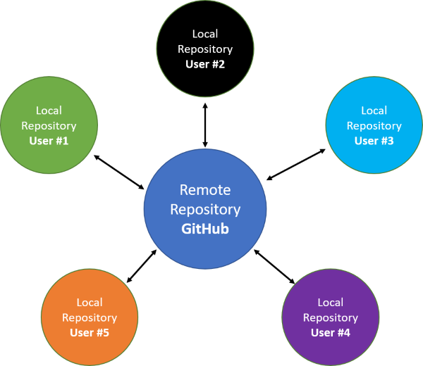

## Git and GitHub Setup

### Any issues with installation or setting up accounts?

## Configuring Git with your name and email

Using Git Bash or command line:

`git config --global user.name 'Your Name'`  
`git config --global user.email 'yourname@domain.com'`  
Check configuration with `git config --global --list`

Using the [`usethis package`](https://usethis.r-lib.org/) in R:

```r
usethis::use_git_config(user.name = "Your Name", user.email = "yourname@domain.com")
```

## Getting Started

## Creating and Cloning Repositories

Purpose: Check configuration on our computers, and introduce basic concepts of Git and GitHub

1. Create a new repository on GitHub
2. Clone the new repository to your local computer using RStudio
   - *File > New Project > Version Control > Git*
   - Copy the URL of your new GitHub repository and paste it into “repository URL”
3. Check if you have a local repository stored on your computer

## Commit and Push from Local Repository

1. Make a change to the README file in your local repository
2. Stage and commit this change using the Git pane in RStudio
3. Push your commit to your remote repository on GitHub
   - If you are a new GitHub user, you will be asked to provide your username and password
4. Check if your local change is now on your GitHub remote
5. Repeat the steps above to check if your GitHub credentials were cached properly (You should **NOT** be asked for your username and password a second time)

## Commit in GitHub and Pull into Local Repository

1. Make a change to the README file in your remote repository on GitHub
2. Commit this change in GitHub
3. Pull change into your local repository using the Git pane in RStudio
4. Confirm that the change is now in your local repository

## Collaborating with Others

## Cloning vs. Forking Repositories

Clone:

- A copy of a remote repository stored as a local repository on your computer
- Able to push, fetch, and pull changes directly with the remote repository
- Usually the configuration with your own repositories or with other repositories that you are a collaborator on

Fork:

- A special configuration which is usually a copy of someone else’s repository
- Able to fetch and pull changes and make edits on your forked copy
- **NOT** able to directly push edits to the original repository, only to the forked repository
- Usually the configuration when you create pull requests or when you are not a collaborator on a public repository

## Adding Collaborators

Allows for others to clone your repository and directly push, fetch, and pull changes

1. Open up “Settings” in your remote repository on GitHub
2. Select “Manage access” and then “Invite a collaborator”
3. Enter the username of your collaborator
4. A confirmation email will be sent to your collaborator. Wait for them to confirm.

## Avoiding Merge Conflicts

A merge conflict occurs when 2 people change the same lines in the same file without first pulling in the changes that the other has made. This is always a possibility when 2 or more people are actively working on a repository.

How to avoid:

- Communicate often with your collaborators
- Pull each time you open up the project in RStudio
- Use the workflow: *Pull > Edit > Pull > Commit > Push*
- Pull before every commit, and commit often

## General Workflows

## Creating Repositories

1. Create a new repository on GitHub
2. Clone the new repository to your local computer using one of the following methods:
   - RStudio: *File > New Project > Version Control > Git*
   - Git Bash or command line: `git clone <repo URL>`
   - Using the [`usethis package`](https://usethis.r-lib.org/) in R:

```r
usethis::create_from_github("repo URL")
```

**TIP:** Use a consistent directory on your computer for your local Git repositories

## Committing Changes

1. Make some changes to the repository
2. Stage the changes using one of the following methods:
   - RStudio: check the box next to the file(s) you would like to commit in the Git pane
   - Git Bash or command line: `git add <directory or file>`
3. Commit staged changes using one of the following methods:
   - RStudio: use the commit window accessed from the Git pane
   - Git Bash or command line: `git commit -m "<message>"`

**TIP:** Make each commit for one specific change to the repository

## Pushing and Pulling

Push:

- RStudio: use the button in the Git pane
- Git Bash or command line: `git push <remote> <branch>`

Push one or more commits to the remote repository once you have a finished product or fix

Pull:

- RStudio: use the button in the Git pane
- Git Bash or command line: `git pull <remote>`

For shared repositories, it is good practice to pull in the most recent changes in the remote repository at the beginning of your session and before you commit.

## Sources and Useful References

- Some of the information in this presentation is from the [Happy Git and GitHub for the useR](https://happygitwithr.com/) web document, which is a helpful resource.
- [GitHub help pages](https://docs.github.com/en)
- [GitHub Cheat Sheet](https://education.github.com/git-cheat-sheet-education.pdf)
- [Atlassian Cheat Sheet](https://www.atlassian.com/git/tutorials/atlassian-git-cheatsheet)
- The [`usethis package`](https://usethis.r-lib.org/) has some useful R functions for working with GitHub and pull requests
- Google search or Stack Overflow

## More advanced topics to possibly cover

- Resolving merge conflicts
- Commit history and diff
- gitignore file
- Undoing changes
- Branches
- Pull requests
- Merging branches